# SI370 Winter 2018 -- Assignment 5

### 1c: Calculate the correlation (using the appropriate one based on your normality analysis above) between each pair of fruit in a smoothie (a correlation matrix is probably the easiest way to do this). We think our employees are working independently. Do you see anything that would make suspect this is not true? (5 points)

|  | apples | blueberries | cherries |
| --- | --- | --- | --- |
| apples | 1.000000 | -0.007223 | -0.138319 |
| blueberries | -0.007223 | 1.000000 | 0.212556 |
| cherries | -0.138319 | 0.212556 | 1.000000 |

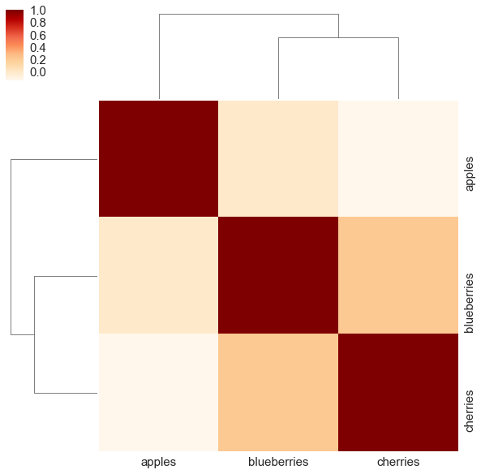

```python
sns.clustermap(cleanedSmoothies.corr(),cmap=plt.cm.OrRd)
cleanedSmoothies.corr()
# A correlation of .212 between cherries and blueberries indicates that there is a slight relationship.
```

### 1d: Later on, we're going to run some regressions and it will make sense to normalize all the data to z-scores. For each fruit, do a z-score normalization. Put the result into a new dataframe called smoothiesZ. (5 points)

```python
smoothiesZ = cleanedSmoothies.copy()
import sklearn.preprocessing as skp

smoothiesZ.ix[:,:9] = skp.scale(smoothiesZ.astype(np.float))
smoothiesZ.head()
```

|  | apples | blueberries | cherries |
| --- | --- | --- | --- |
| 0 | -2.840415 | 0.195251 | 0.872951 |
| 1 | -1.719199 | 0.643532 | -0.383487 |
| 2 | -1.452242 | -0.651502 | 1.364600 |
| 3 | -1.452242 | 1.042004 | -0.547370 |
| 4 | -1.185286 | -0.551884 | 0.053535 |

# Problem 2

We want to figure out what makes a smoothie taste good. We hired some judges to taste each of the 50 variants our employees made and recorded their scores (on a scale of 1 to 10). Let's load up the data.

```python
scores = pd.DataFrame.from_csv('scoresheet.csv')
scores.sample(5)
```

|  | judge 1 | judge 2 | judge 3 |
| --- | --- | --- | --- |
| 48 | 6 | 10 | 8 |
| 26 | 3 | 7 | 5 |
| 0 | 5 | 9 | 7 |
| 49 | 4 | 8 | 6 |
| 7 | 4 | 8 | 6 |

### 2a: We're going to average the scores to find an overall rating for each batch. Unfortunately, sometimes judges tend to just be nicer and give higher scores (or conversely, meaner). Plot the score distribution for each judge to check this. (5 points)

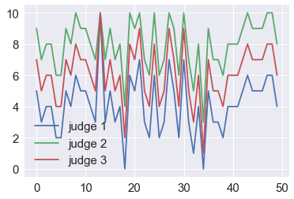

```python
scores.plot()
```

### 2b: If you see some bias (tell us if you do), you may want to use a z-score normalization on each judge's score. Whether you do so or not, create a new DataFrame called extendedScores that contains the average score for each batch based on the three judges (call this column 'avg_score'). (5 points)

```python
#Judge 2 gives the highest scores.
#Judge 1 gives the lowest scores.
```

```python
extendedScores = scores.copy()
```

```python
col = extendedScores.loc[: , "judge 1":"judge 3"]
extendedScores['mean'] = col.mean(axis=1)
extendedScores.head(5)
```

|  | judge 1 | judge 2 | judge 3 | mean |
| --- | --- | --- | --- | --- |
| 0 | 5 | 9 | 7 | 7.0 |
| 1 | 3 | 7 | 5 | 5.0 |
| 2 | 4 | 8 | 6 | 6.0 |
| 3 | 4 | 8 | 6 | 6.0 |
| 4 | 2 | 6 | 4 | 4.0 |

### 2c: Merge the extendedScores table into the smoothiesZ table. The smoothiesZ table should contain the fruit columns, the individual judges, and avg_score. (3 points)

```python
#pd.merge(extendedScores, smoothiesZ, on='subject_id', how='outer')
smoothiesZ = pd.concat([extendedScores, smoothiesZ], axis=1)
```

```python
smoothiesZ.head()
```

|  | judge 1 | judge 2 | judge 3 | mean | apples | blueberries | cherries |
| --- | --- | --- | --- | --- | --- | --- | --- |
| 0 | 5 | 9 | 7 | 7.0 | -2.840415 | 0.195251 | 0.872951 |
| 1 | 3 | 7 | 5 | 5.0 | -1.719199 | 0.643532 | -0.383487 |
| 2 | 4 | 8 | 6 | 6.0 | -1.452242 | -0.651502 | 1.364600 |
| 3 | 4 | 8 | 6 | 6.0 | -1.452242 | 1.042004 | -0.547370 |
| 4 | 2 | 6 | 4 | 4.0 | -1.185286 | -0.551884 | 0.053535 |

# Problem 3

We're now going to try to learn a model that predicts the score given the fruit distribution. We're going to use the OLS regression as before, but we now have more variables to play with, so we will create a model with multiple independendent variables. It may be that score only depends on apples, or maybe on some combination of apples and cherries, or maybe some other combination.

The statsmodel package let's us write these models as simple formulas:

- avg_score ~ apples
- avg_score ~ apples + blueberries
- ...

The code for a model containing apples and cherries would be:

```python
model1 = smf.ols('mean ~ apples + cherries', data=smoothiesZ).fit()
model1.summary()
```

OLS Regression Results

| Dep. Variable: | mean | R-squared: | 0.680 |
| --- | --- | --- | --- |
| Model: | OLS | Adj. R-squared: | 0.666 |
| Method: | Least Squares | F-statistic: | 49.91 |
| Date: | Thu, 15 Feb 2018 | Prob (F-statistic): | 2.37e-12 |
| Time: | 07:58:35 | Log-Likelihood: | -70.414 |
| No. Observations: | 50 | AIC: | 146.8 |
| Df Residuals: | 47 | BIC: | 152.6 |
| Df Model: | 2 |  |  |
| Covariance Type: | nonrobust |  |  |

|  | coef | std err | t | P>\|t\| | [0.025 | 0.975] |
| --- | --- | --- | --- | --- | --- | --- |
| Intercept | 6.0667 | 0.144 | 42.036 | 0.000 | 5.776 | 6.357 |
| apples | 0.4259 | 0.146 | 2.923 | 0.005 | 0.133 | 0.719 |
| cherries | 1.4376 | 0.146 | 9.866 | 0.000 | 1.144 | 1.731 |

| Omnibus: | 3.263 | Durbin-Watson: | 2.319 |
| --- | --- | --- | --- |
| Prob(Omnibus): | 0.196 | Jarque-Bera (JB): | 2.227 |
| Skew: | -0.440 | Prob(JB): | 0.328 |
| Kurtosis: | 3.542 | Cond. No. | 1.15 |

### 3a: Find the best model (the one with the highest R-squared). Fill in the list below with the r-squared you found. Call the best model you find "modelBest". (9 points)

- apples: [.017]
- blueberries: [.339]
- cherries: [.622]
- apples + blueberries: [.357]
- apples + cherries: [.680]
- blueberries + cherries: [.802]
- apples + blueberries + cherries: [.855]

```python
model2 = smf.ols('mean ~ apples', data=smoothiesZ).fit()
model2.summary()
model3 = smf.ols('mean ~ blueberries', data=smoothiesZ).fit()
model3.summary()
model4 = smf.ols('mean ~ cherries', data=smoothiesZ).fit()
model4.summary()
model5 = smf.ols('mean ~ apples + blueberries', data=smoothiesZ).fit()
model5.summary()
model6 = smf.ols('mean ~ apples + cherries', data=smoothiesZ).fit()
model6.summary()
model7 = smf.ols('mean ~ blueberries + cherries', data=smoothiesZ).fit()
model7.summary()
model8 = smf.ols('mean ~ apples + blueberries + cherries', data=smoothiesZ).fit()
model8.summary()
```

OLS Regression Results

| Dep. Variable: | mean | R-squared: | 0.855 |
| --- | --- | --- | --- |
| Model: | OLS | Adj. R-squared: | 0.846 |
| Method: | Least Squares | F-statistic: | 90.57 |
| Date: | Thu, 15 Feb 2018 | Prob (F-statistic): | 2.54e-19 |
| Time: | 07:58:35 | Log-Likelihood: | -50.577 |
| No. Observations: | 50 | AIC: | 109.2 |
| Df Residuals: | 46 | BIC: | 116.8 |
| Df Model: | 3 |  |  |
| Covariance Type: | nonrobust |  |  |

|  | coef | std err | t | P>\|t\| | [0.025 | 0.975] |
| --- | --- | --- | --- | --- | --- | --- |
| Intercept | 6.0667 | 0.098 | 61.838 | 0.000 | 5.869 | 6.264 |
| apples | 0.4090 | 0.099 | 4.128 | 0.000 | 0.210 | 0.608 |
| blueberries | 0.7496 | 0.100 | 7.464 | 0.000 | 0.547 | 0.952 |
| cherries | 1.2760 | 0.101 | 12.584 | 0.000 | 1.072 | 1.480 |

| Omnibus: | 2.447 | Durbin-Watson: | 2.065 |
| --- | --- | --- | --- |
| Prob(Omnibus): | 0.294 | Jarque-Bera (JB): | 1.435 |
| Skew: | -0.076 | Prob(JB): | 0.488 |
| Kurtosis: | 2.184 | Cond. No. | 1.29 |

```python
bestModel = smf.ols('mean ~ apples + blueberries + cherries', data=smoothiesZ).fit()
bestModel.summary()
```

OLS Regression Results

| Dep. Variable: | mean | R-squared: | 0.855 |
| --- | --- | --- | --- |
| Model: | OLS | Adj. R-squared: | 0.846 |
| Method: | Least Squares | F-statistic: | 90.57 |
| Date: | Thu, 15 Feb 2018 | Prob (F-statistic): | 2.54e-19 |
| Time: | 07:58:35 | Log-Likelihood: | -50.577 |
| No. Observations: | 50 | AIC: | 109.2 |
| Df Residuals: | 46 | BIC: | 116.8 |
| Df Model: | 3 |  |  |
| Covariance Type: | nonrobust |  |  |

|  | coef | std err | t | P>\|t\| | [0.025 | 0.975] |
| --- | --- | --- | --- | --- | --- | --- |
| Intercept | 6.0667 | 0.098 | 61.838 | 0.000 | 5.869 | 6.264 |
| apples | 0.4090 | 0.099 | 4.128 | 0.000 | 0.210 | 0.608 |
| blueberries | 0.7496 | 0.100 | 7.464 | 0.000 | 0.547 | 0.952 |
| cherries | 1.2760 | 0.101 | 12.584 | 0.000 | 1.072 | 1.480 |

| Omnibus: | 2.447 | Durbin-Watson: | 2.065 |
| --- | --- | --- | --- |
| Prob(Omnibus): | 0.294 | Jarque-Bera (JB): | 1.435 |
| Skew: | -0.076 | Prob(JB): | 0.488 |
| Kurtosis: | 2.184 | Cond. No. | 1.29 |

### 3b: Plot the "four plots" for the residuals. Does anything look weird? (not-normal? not independent? not equal variance?). Hint: you can calculate this directly from the coeffients in the model, or just use the studentized residuals column in the influential points table the model generates (where we usually get dfitts, etc.) (9 points)

If you see a weird residual, you may want to remove the influential point (but as another hint: you probably shouldn't need to here)

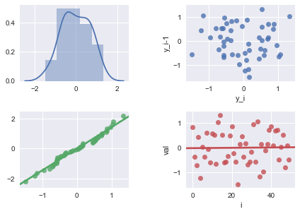

```python
fourPlot(bestModel.resid)
# Nothing looks weird
```

# Problem 4

Our daily quality score is simply the mean of the avg_scores:

`daily_score = np.mean(smoothiesZ.avg_score)`

Before investing in any new equipment or processes we want to know how bad (or good) this score is. Essentially, we want a confidence interval.

### 4a: Calculate and plot the 95 percentile CI for the daily_score using bootstrapping. (9 points)

```python
smoothiesZ=smoothiesZ.rename(columns = {'mean':'avg_score'})
daily_score = np.mean(smoothiesZ.avg_score)

reps = 10000
xb = np.random.choice(smoothiesZ['avg_score'],(reps,len(smoothiesZ)))
xb.shape
```

```
(10000, 50)
```

```python
mb = xb.mean(axis=1)
mb[0:10]
```

```
array([ 5.8       ,  5.92666667,  5.67333333,  6.22      ,  5.93333333,
        6.14      ,  6.19333333,  6.52      ,  6.04      ,  5.98666667])
```

```
mean= 6.065522
stdev= 0.24766944091
[ 5.58        6.54666667]
```

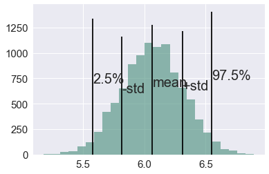

```python
ptile = np.percentile(mb,[2.5,97.5])
ax = sns.distplot(mb,25,kde=False)  # 25 bins
print("mean=",np.mean(mb))
print("stdev=",np.std(mb))
vline(ax,np.mean(mb)-np.std(mb),"-std")
vline(ax,np.mean(mb)+np.std(mb),"+std")
vline(ax,np.mean(mb),"mean")
print(ptile)  # two cutoffs, one at 2.5% one at 97.5%
ax = sns.distplot(mb,25,kde=False)
vline(ax,ptile[0],"2.5%")  # label the two cutoffs
vline(ax,ptile[1],"97.5%")
```

### 4b: Calculate the mean and std of this simulation. From this, you should be able to generate a reasonable model of your score (the possible values you'll get on any day). (5 points)

For example, if your mean is 5 and std is 20, you could generate a guess about 30 future days by doing:

`np.random.normal(loc=5, scale=20, size=30)`

```
mean= 6.065522
stdev= 0.24766944091
```

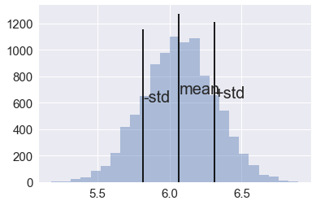

```python
ax = sns.distplot(mb,25,kde=False)  # 25 bins
print("mean=",np.mean(mb))
print("stdev=",np.std(mb))
vline(ax,np.mean(mb)-np.std(mb),"-std")
vline(ax,np.mean(mb)+np.std(mb),"+std")
vline(ax,np.mean(mb),"mean")
```

```python
np.random.normal(loc=np.mean(mb), scale=np.std(mb), size=30)
```

```
array([ 6.05353317,  5.99313541,  5.91260222,  6.35661599,  6.32946071,
        6.0595942 ,  5.94697385,  6.0863693 ,  6.29604719,  5.86600421,
        6.15937271,  5.98297877,  6.24337039,  5.57541274,  6.36327824,
        6.48849146,  6.15586443,  5.89105461,  6.22183111,  6.06956359,
        6.13731677,  5.95908388,  6.17957236,  6.10075916,  5.67901187,
        6.13483399,  5.98389458,  6.62759271,  6.14294848,  5.95043372])
```

# Problem 5

A smoothie equipment vendor comes in and says the can improve your (z-normalized) score by .06 points. Essentially, what the company is telling you is that if your score distribution was normal (as you calculated above) with a mean of 1 and stdev of .2 (both made up). You'll now be at a mean of 1.06 (and still have a stdev of .2)

The equipment is very expensive, so you're going to need to hire more judges to sample batches of the old and new. The difference should very clear and very significant (i.e., p < .01). You want to be really confident that the judges will catch the difference (a power of 90% or .9).

Just to get you started, let's say the original process gave us a mean score of 0, and stdev of .1. The new process should be at a mean of .06 and stdev of .1. If we generated only 6 samples of each, the p-value will be usually be pretty high (not significant). You can change the value of n in the cell below. Run it multiple times to see if you get a significant p-value.

```
samples= 41 , t= -0.722047333365 , p= 0.47237067873
```

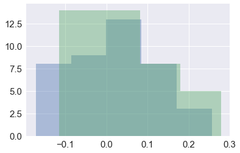

```python
n = 41
origProcess = np.random.normal(0, .1, size=n)
newProcess = np.random.normal(.06, .1, size=n)
sns.distplot(origProcess,kde=False)
sns.distplot(newProcess,kde=False)

t, p = stats.ttest_ind(origProcess, newProcess)
print("samples=",n,", t=",t,", p=",p)
```

### Do a power calculation (by simulation) to find the number of samples you'd need to have a power of 90% of rejecting the null hypothesis at .01 (on this .06 improvement). (15 points)

```python
nreps = 10000   # number of experiments
n = 20 # number of samples to start
power = 0 # starting point for power

while power < 0.9:  # stop if we hit .9
    origProcess = np.random.normal(0, .1, (n, nreps))
    newProcess = np.random.normal(.06, .1, (n, nreps))
    t, p = stats.ttest_ind(origProcess, newProcess)
    power = (p < 0.01).sum()/nreps
    print(n, power)  # print the sample size and power achieved
    n += 1  # add one more to the samples
```

```
20 0.2235
21 0.2282
22 0.2431
23 0.2694
24 0.2807
25 0.2994
26 0.316
27 0.3256
28 0.3389
29 0.3567
30 0.3777
31 0.3918
32 0.4041
33 0.4246
34 0.4397
```

[output cut: 50 more lines]

```python
# Lowest sample size is 84.
```